# HW01-Chap3-XinqianCai

Xinqian Cai

2022/1/16

##Q1 1. What is a variable? A: the context of empirical research, a variable is a bunch of observations of the same measurement.

##Q2 2. For each of the following variables, what types of variables are they (continuous, count, ordinal, categorical, qualitative)? a. Age - continuous

2. Gender - categorical
3. The number of times that the President has tweeted in the past day - count
4. Income - continous
5. Number of Instagram posts about statistics in the past month - count
6. The number of unemployment claims filed in US last week - count
7. The university or college that a student attends - categorical
8. A therapist’s written assessment of a patient’s symptoms of depression - qualitative
9. Whether a soccer team is in its league’s A division (highest), B division (next highest), or C division (lowest) - ordinal

##Q3 3. Which of the following provides a description of the probability that each possible value of a variable will occur? A: b. Distribution

1. Variation
2. Distribution
3. Range
4. Mean

##Q4 4. Below is a frequency table depicting the salaries of Economics professors employed at a university. The column named Salary contains the salary, and the column named Frequency contains the number of professors who earn the stated salary.

Salary Frequency $85,000 5 $90,000 4 $100,000 1 $120,000 2 $125,000 3 $130,000 2

1. Calculate the average salary earned by professors in the Economics department.

```r
mean<- (85000*5+90000*4+100000*1+120000*2+125000*3+130000*2)/(5+4+1+2+3+2)
mean
```

```
## [1] 103529.4
```

2. Calculate the median.

Since there is 17 observations in this sample, the median observation is the 9th observation. Therefore, the median is 90,000.

3. Calculate the minimum and maximum.

The minimum is 85,000; the maximum is 130,000.

4. Calculate the interquartile range.

In this sample, the 25th percentile is 85,000; the 75th percentile is 125,000. Therefore, the interquartile range is 40,000. (125,000-85,000=40,000)

##Q5 5. Which of the following commonly represents the truth we are trying to estimate in statistics? A: c. Greek letters. (Greek letters represent the truth, and the modification represent our estimate of the truth.)

1. English/Latin letters like x and y
2. Modifications of English letters like x ̅
3. Greek letters like μ and β
4. Modifications of Greek letters like β ̂

##Q6 6. Which of the following reduces impact of extreme values if the distribution of a variable is skewed? A: a. Log transforming the variable.

1. Log transforming the variable
2. Mean centering the variable
3. Standardizing the variable
4. Ignoring the variable

1. Describe the distribution.

2. Is there skewness to the data?

Yes, there is skewness to the data. The distribution is right-skewed.

3. Would the mean or the median be a better measure to describe the center of the distribution?

Median is better than mean as a measure to describe the center of the distribution because this distribution is right-skewed though this distribution is not that highly-skewed.

4. What measure would you use to describe the variability in the distribution?

I would like to use interquartile range to measure the variability in this distribution because this distribution is a little bit right-skewed. But I think the variance and standard deviation are both useful to describe the variability in this distribution since this distribution is not that highly-skewed. So I think the right tail will not have great impact on the variance.

##Q9 9. Which of the following statement is correct regarding a left-skewed distribution? A: b. The mean is less than the median.

1. The mean is greater than the median
2. The mean is less than the median
3. The mean and median are equal

##Q10 10. The table below shows data on how many students in a university are Freshman, Sophomore, Junior and Senior.

Student Standing Frequency Freshman 1000 Sophomore 1200 Junior 900 Senior 1500

1. For an individual student, what kind of variable is their student standing (continuous, count, ordinal, categorical, qualitative)?

A:Categorical variable.

2. For the university itself, what kind of variable is the number of students with a given student standing (continuous, count, ordinal, categorical, qualitative)? (Yes, the answer is different from part a!)

A:Count variable.

3. What kind of graph would best visualize this distribution for the university? Create the graph either by hand or with software.

A: A bar graph would best visualize this distribution for the university.

```r
df1<-data.frame(studentstanding=c("Freshman", "Sophomore", "Junior","Senior"), frequency = c(1000,1200,900,1500))
library(tidyverse)
```

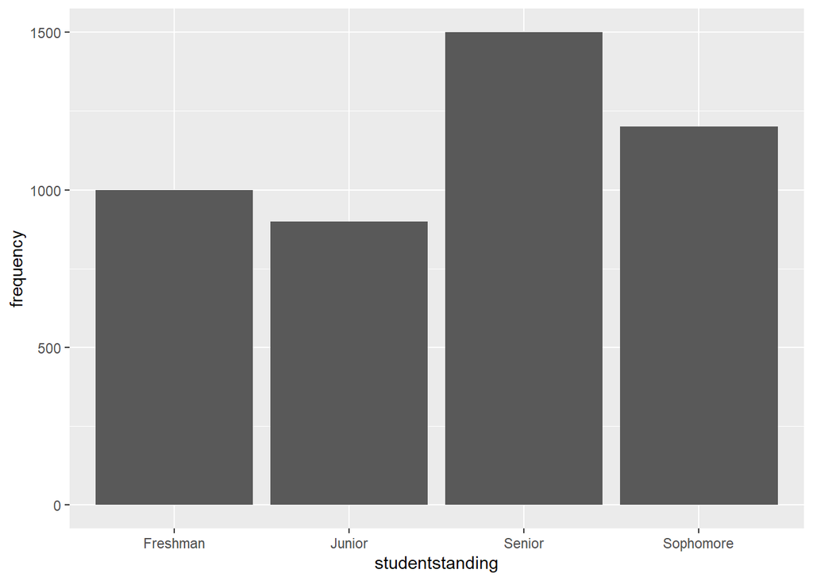

```r
ggplot(df1,aes(x=studentstanding,y=frequency))+
  geom_col()
```

##Q11 11. Collect any continuous data from your classmates, family members, and/or friends. For example, you can collect data about their age or height.

```r
df2<-data.frame(observation=c("Friend1", "Friend2", "Friend3","Friend4","Friend5", "Friend 6", "Friend7", "Friend8","Friend9","Friend10","Friend11","Friend12","Friend13","Friend14","Friend15","Friend16","Friend17","Friend18","Friend19","Friend20","Friend21"), height = c(155,160,161,170,180,188,163,167,163,165,165,160,158,158,177,180,164,171,170,180,166))
df2
```

```
##    observation height
## 1      Friend1    155
## 2      Friend2    160
## 3      Friend3    161
## 4      Friend4    170
## 5      Friend5    180
## 6     Friend 6    188
## 7      Friend7    163
## 8      Friend8    167
## 9      Friend9    163
## 10    Friend10    165
## 11    Friend11    165
## 12    Friend12    160
## 13    Friend13    158
## 14    Friend14    158
## 15    Friend15    177
## 16    Friend16    180
## 17    Friend17    164
## 18    Friend18    171
## 19    Friend19    170
## 20    Friend20    180
## 21    Friend21    166
```

1. What is the distribution of the data? Describe the shape of the distribution. Summarize the data using measures like mean, median, range, standard deviation.

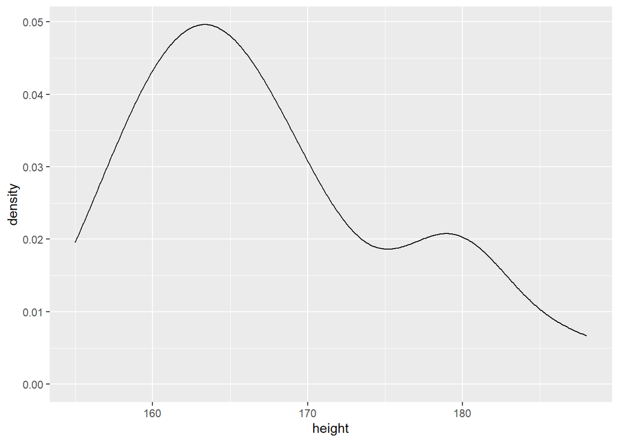

```r
ggplot(df2,aes(x=height))+
  geom_density()
```

```r
df2|>
  summarize(mean=mean(height),
            median=median(height),
            range=range(height),
            sd=sd(height))
```

```
##       mean median range       sd
## 1 167.6667    165   155 8.839306
## 2 167.6667    165   188 8.839306
```

This distribution is a bimodal distribution. The distribution first increases between 155 and around 163 and then decreases between around 163 and 175. Next, it increases between 175 and around 178, and finally decreases. The mean is 167.6667; the median is 165; the range is from 155 to 188; the standard deviation is 8.839306.

2. What theoretical distribution may have generated the data that you sampled? A normal distribution with a mean of 168 could be the theoretical distribution that may have generated the data that I sampled.

```r
#Assume the standard deviation of the truth is 10.
sd_mean<-10/(21^(1/2))
sd_mean
```

```
## [1] 2.182179
```

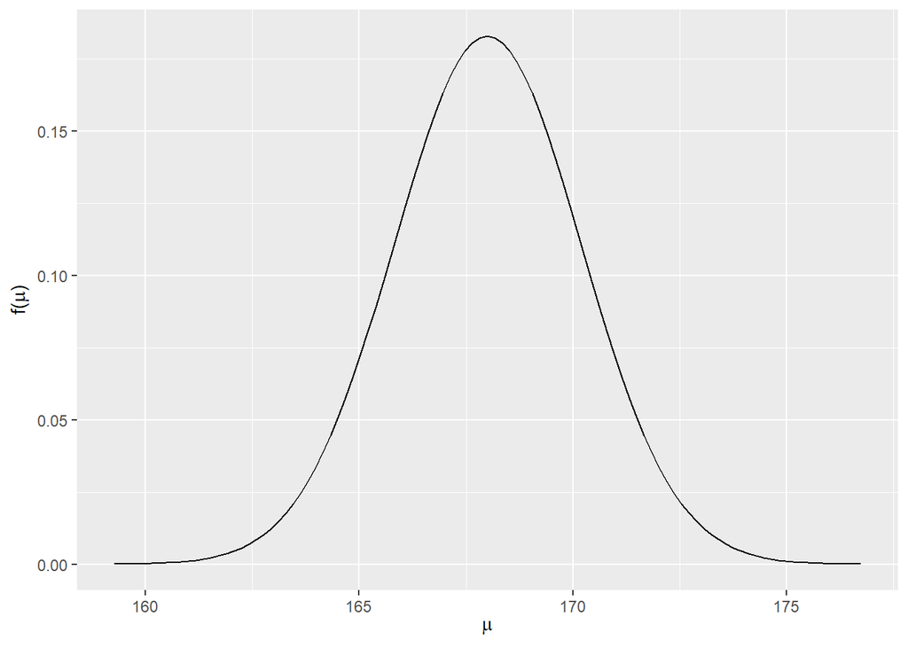

```r
#A normal distribution with a mean of 168 and a standard deviation of 2.182179
library(bayesrules)
library(tidyr)
library(tidyverse)
plot_normal(168,sd_mean)
```

```r
#Calculate the 2.5 percentile and the 97.5 percentile
qnorm(0.025,mean = 168,sd=sd_mean)
```

```
## [1] 163.723
```

```r
qnorm(0.975,mean =168, sd=sd_mean)
```

```
## [1] 172.277
```

```r
#Based on the result above, the mean of my sample,167.6667 is between the 2.5 percentile value and the 97.5 percentile value.
```

3. Does your data give you a good idea about what the underlying theoretical distribution might be? Explain your reasoning.

No, I do not think that my data give me a quite good idea about what the underlying theoretical distribution might be. My sample is not normally distributed, instead of a bimodal distribution. Therefore, maybe I might need to get more data. Or I might need to build up my sample based on different gender because I guess that it is the gender that causes the bimodal distribution.